# CTA Example

Christopher Barrie

2022-03-30

## Example

We generally include all of the libraries required at the top of the script as so.

```r
library(haven)
library(quanteda)
```

```r
library(quanteda.textstats)
library(ggplot2)
```

We can read the main “Motif” dataset from this dataset (stored in Stata .dta format) as follows.

```r
folklore <- read_dta("/Users/cbarrie6/Dropbox/Teaching/Edinburgh/teaching/CTA_21-22/CTA-ED/data/assessment/Motif_Master.dta")
```

## Including outputs

You can also embed outputs like plots that you generate from the data. For example, if I had decided to plot the highest frequency words in the motifs data, I might do the following.

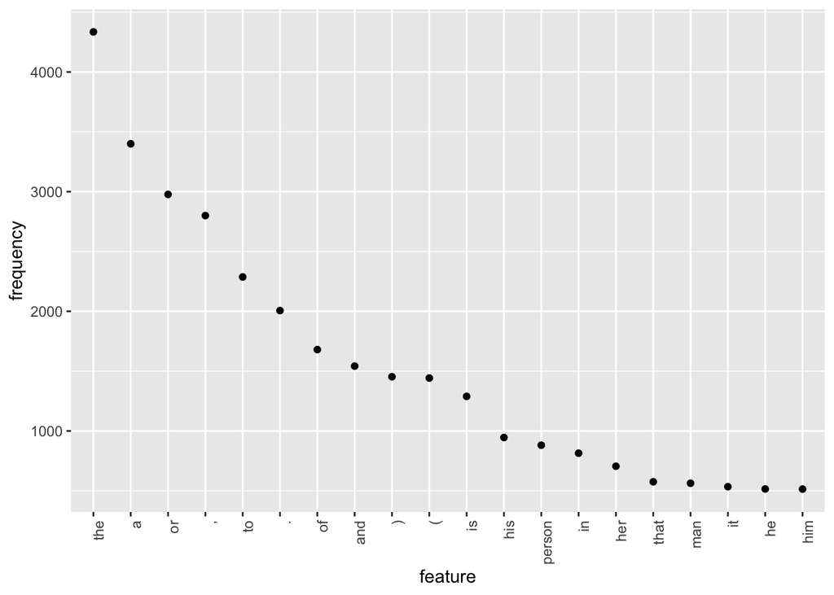

```r
folk_dfm <- dfm(tokens(folklore$desc_eng))

folk_dfm_features <- textstat_frequency(folk_dfm, n = 20)

# Sort by reverse frequency order
folk_dfm_features$feature <- with(folk_dfm_features, reorder(feature, -frequency))

ggplot(folk_dfm_features, aes(x = feature, y = frequency)) +
    geom_point() +
    theme(axis.text.x = element_text(angle = 90, hjust = 1))
```

## Static code rendering

Note that we can also add the `eval = FALSE` parameter to our code chunk, which means that the code won’t run when we knit the file: instead, it will just format the code in a visually appealing way and make it more legible.

If we did not want to include any of the output, and just the code, we could do the following, and include all of our code in one chunk, output as a Word document.

```r
library(haven)
library(quanteda)
library(quanteda.textstats)
library(ggplot2)

# read in the data
folklore <- read_dta("/Users/cbarrie6/Dropbox/Teaching/Edinburgh/teaching/CTA_21-22/CTA-ED/data/assessment/Motif_Master.dta")

# generate dfm from descriptions
folk_dfm <- dfm(tokens(folklore$desc_eng))

# get dfm features (word frequencies)
folk_dfm_features <- textstat_frequency(folk_dfm, n = 20)

# Sort by reverse frequency order
folk_dfm_features$feature <- with(folk_dfm_features, reorder(feature, -frequency))

# plot in descending order
ggplot(folk_dfm_features, aes(x = feature, y = frequency)) +
    geom_point() +
    theme(axis.text.x = element_text(angle = 90, hjust = 1))
```

## Output formats

Finally, note that if you change the YAML metadata at the top of this document from `output: word_document` to `output: html_document` you will generate a nicely formatted html document. For this assignment, stick with `output: word_document` to avoid any ELMA headaches…